# Data visualization with ggplot2

### Section 2 - Histograms

#### Common plot types

- Bar plots
  - Histogram, bar, col, errorbar

#### Histograms

- A plot of binned values
  - i.e. a statistical function

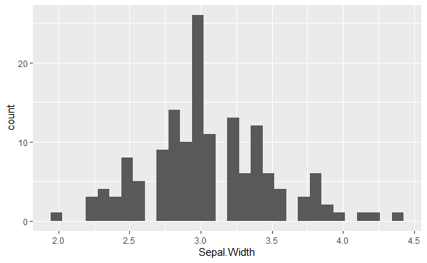

```r
ggplot(iris, aes(x = Sepal.Width)) + geom_histogram()
```

- Geom is associated with a particular statistic - ‘stat_bin()’
  - Default = 30

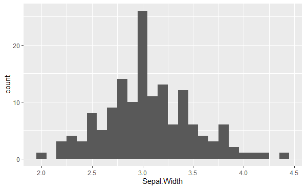

```r
ggplot(iris, aes(x = Sepal.Width)) +
  geom_histogram(binwidth = 0.1)
```

- Always set meaningful bin widths for your data
- No spaces between bars
- x-labels are between bars

#### Re-position tick marks

```
Ignoring unknown parameters: ceneter
```

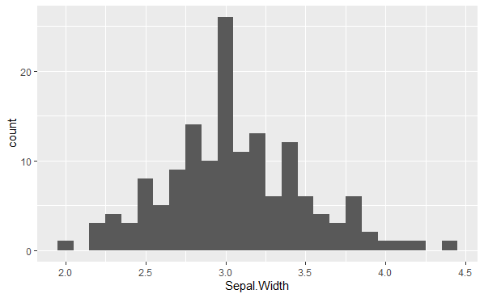

```r
ggplot(iris, aes(x = Sepal.Width)) +
  geom_histogram(binwidth = 0.1,
                 ceneter = 0.05)
```

#### Different species

```
Ignoring unknown parameters: ceneter
```

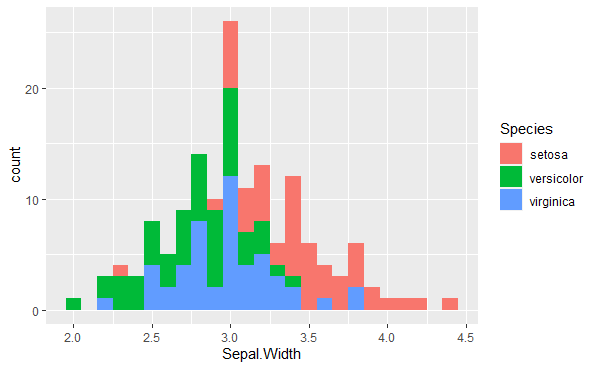

```r
ggplot(iris, aes(x = Sepal.Width, fill = Species)) +
  geom_histogram(binwidth = 0.1,
                 ceneter = 0.05,
                 position = 'stack')
```

- Difficult to see if bars overlapping or stacked - default is stacked
- Can also `dodge` bars - offset

```
Ignoring unknown parameters: ceneter
```

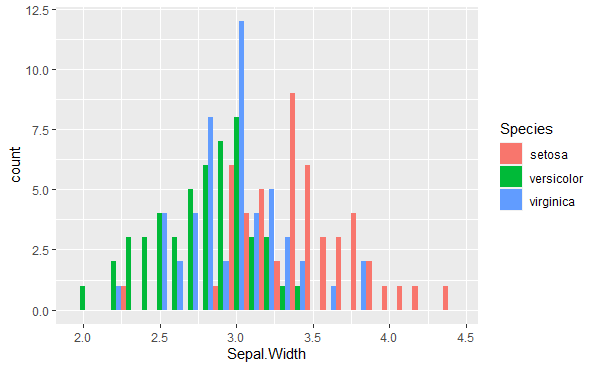

```r
ggplot(iris, aes(x = Sepal.Width, fill = Species)) +
  geom_histogram(binwidth = 0.1,
                 ceneter = 0.05,
                 position = 'dodge')
```

- `position = "fill"`
  - Fills to represent the proportion of all observations

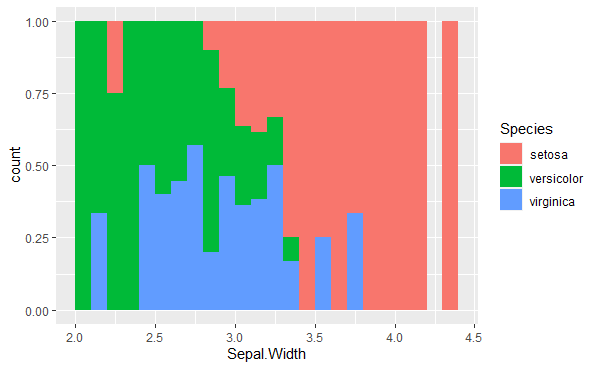

```r
ggplot(iris, aes(x = Sepal.Width,
                 fill = Species)) +
  geom_histogram(binwidth = 0.1,
                 center = 0.05,
                 position = 'fill')
```

- An internal variable called `density`, can be accessed by using the `..` notation, i.e. `..density..`
- Plotting this variable will show the relative frequency, which is the height times the width of each bin (i.e. normalises the histogram)

### Section 3 - Bar plots

# Bar plots, with a categorical x-axis

- Use `geom_bar()` or `geom_col()`
  - `geom_bar()`
    - stat = “count”
    - counts the number of cases at each x position
  - `geom_col()`
    - stat = “identity”
    - plots actual values
- All positions from before are available
- Two types
  - Absolute counts
  - Distributions

#### Habits of mammals

```r
str(msleep)
```

```
tibble [83 x 11] (S3: tbl_df/tbl/data.frame)
 $ name        : chr [1:83] "Cheetah" "Owl monkey" "Mountain beaver" "Greater short-tailed shrew" ...
 $ genus       : chr [1:83] "Acinonyx" "Aotus" "Aplodontia" "Blarina" ...
 $ vore        : chr [1:83] "carni" "omni" "herbi" "omni" ...
 $ order       : chr [1:83] "Carnivora" "Primates" "Rodentia" "Soricomorpha" ...
 $ conservation: chr [1:83] "lc" NA "nt" "lc" ...
 $ sleep_total : num [1:83] 12.1 17 14.4 14.9 4 14.4 8.7 7 10.1 3 ...
 $ sleep_rem   : num [1:83] NA 1.8 2.4 2.3 0.7 2.2 1.4 NA 2.9 NA ...
 $ sleep_cycle : num [1:83] NA NA NA 0.133 0.667 ...
 $ awake       : num [1:83] 11.9 7 9.6 9.1 20 9.6 15.3 17 13.9 21 ...
 $ brainwt     : num [1:83] NA 0.0155 NA 0.00029 0.423 NA NA NA 0.07 0.0982 ...
 $ bodywt      : num [1:83] 50 0.48 1.35 0.019 600 ...
```

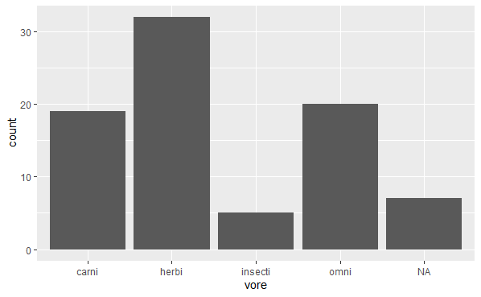

```r
ggplot(msleep, aes(vore)) +
  geom_bar()
```

#### Plotting distributions instead of absolute counts

```r
# Calculate descriptive statistics
library(tidyr)
iris_summ_long <- iris %>%
  select(Species, Sepal.Width) %>%
  gather(key, value, -Species) %>%
  group_by(Species) %>%
  summarise(avg = mean(value),
            stdev = sd(value))

iris_summ_long
```

|  | Species | avg | stdev |
| --- | --- | --- | --- |
| 1 | setosa | 3.428 | 0.3790644 |
| 2 | versicolor | 2.770 | 0.3137983 |
| 3 | virginica | 2.974 | 0.3224966 |

#### Plotting distributions

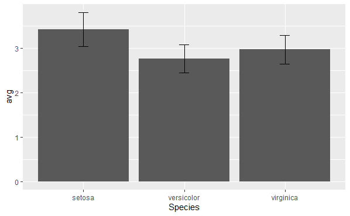

```r
ggplot(iris_summ_long, aes(x = Species,
                           y = avg)) +
  geom_col() +
  geom_errorbar(aes(ymin = avg - stdev,
                    ymax = avg + stdev),
                width = 0.1)
```

### Section 4 - Line plots

```r
str(beaver2)
```

```
'data.frame':   100 obs. of  4 variables:
 $ day  : num  307 307 307 307 307 307 307 307 307 307 ...
 $ time : num  930 940 950 1000 1010 1020 1030 1040 1050 1100 ...
 $ temp : num  36.6 36.7 36.9 37.1 37.2 ...
 $ activ: num  0 0 0 0 0 0 0 0 0 0 ...
```

#### Beaver

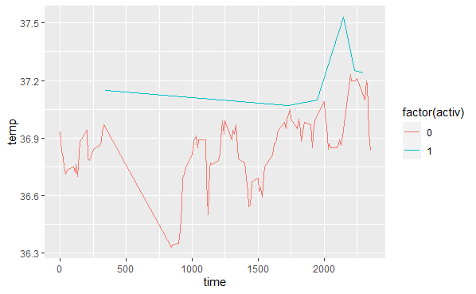

#### Using aesthetics to differentiate multiple series

Options include: - `linetype = Species` - `size = Species` - `color = Species` - `fill = Species` - defaults to geom_stack

#### Aesthetics for categorical variables

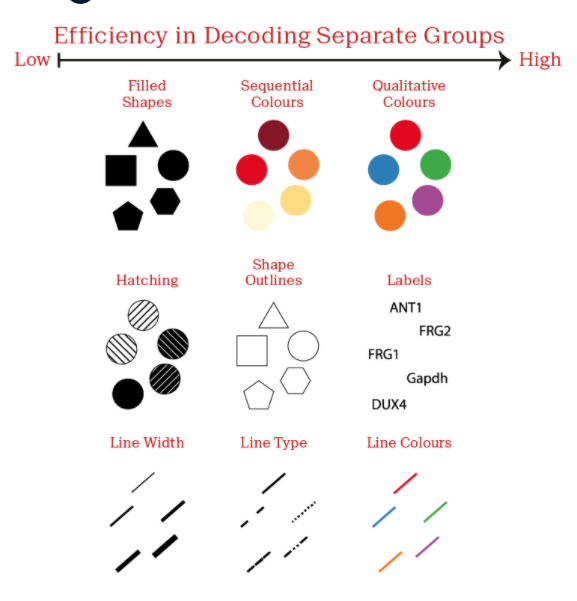

Aesthetics for categorical variables

#### geom_ribbon()

- Used for looking at overlapping areas
- Need to force y-min to be 0

```r
ggplot(fish, aes(x = Year,
                 y = Capture,
                 fill = Species)) +
  geom_ribbon(aes(ymax = Capture, ymin = 0), alpha = 0.3)
```

#### Using groupings

```r
ggplot(fish.tidy, aes(x = Year, y = Capture, color = Species)) +
  geom_line(aes(group = Species))
```